# Case 2_Data Analysis Skill Test - 4intelligence

## Item 4 - Quais países foram os parceiros comerciais mais importantes para o Brasil em termos de ‘milho’ e ‘açúcar’ nos últimos 3 anos?

#### Milho

```r
q4 <- subset(data, type == 'Export' & product %in% c('corn') &
            format(as.Date(date), '%Y') %in% c(as.numeric(max(format(as.Date(data$date), '%Y'))),
                                               as.numeric(max(format(as.Date(data$date), '%Y')))-1,
                                               as.numeric(max(format(as.Date(data$date), '%Y')))-2))  %>%
      select(country, usd) %>%
      group_by(country)  %>%
      summarise_at('usd', sum, na.rm = F)

q4_ordem <- q4[order(q4$usd, decreasing = T),]

q4_ordem[1:5,]
```

```
## # A tibble: 5 x 2
##   country        usd
##   <chr>        <dbl>
## 1 Iran    2822336281
## 2 Japan   1574975592
## 3 Vietnam 1551035208
## 4 Egypt   1375065136
## 5 Spain   1335769607
```

A tabela, acima, apresenta o ranking dos 5 principais parceiros comerciais do Brasil no comércio de `milho`, nos últimos 3 anos.

#### Açúcar

```r
q4_1 <- subset(data, type == 'Export' & product %in% c('sugar') &
            format(as.Date(date), '%Y') %in% c(as.numeric(max(format(as.Date(data$date), '%Y'))),
                                               as.numeric(max(format(as.Date(data$date), '%Y')))-1,
                                               as.numeric(max(format(as.Date(data$date), '%Y')))-2))  %>%
      select(country, usd) %>%
      group_by(country)  %>%
      summarise_at('usd', sum, na.rm = F)

q4_1_ordem <- q4_1[order(q4_1$usd, decreasing = T),]

q4_1_ordem[1:5,]
```

```
## # A tibble: 5 x 2
##   country                     usd
##   <chr>                     <dbl>
## 1 Algeria              2176380928
## 2 Bangladesh           2063174600
## 3 India                1696094938
## 4 United Arab Emirates 1538397895
## 5 Saudi Arabia         1380455693
```

A tabela, acima, apresenta o ranking dos 5 principais parceiros comerciais do Brasil no comércio de `açúcar`, nos últimos 3 anos.

## Item 5 - Para cada um dos produtos no conjunto de dados, apresente os 5 estados mais importantes em termos de exportações?

```r
q5 <- function(product) { paste("SELECT product, state, SUM(usd)
                                    FROM data
                                    WHERE product = '",product,"' and type = 'Export'
                                    GROUP BY product, state
                                    ORDER BY 3 DESC
                                    LIMIT 5", sep = "", collapse = "")}

df <- data.frame()

for (i in 1:length(levels(as.factor(data$product)))) {

  result <- sqldf(q5(levels(as.factor(data$product))[i]))
  df <- rbind(df,result)}

colnames(df) <- c('Produto','Estado','Dólares')

df
```

```
##         Produto Estado     Dólares
## 1          corn     MT 28375516035
## 2          corn     PR  9160511995
## 3          corn     GO  5706990655
## 4          corn     MS  3405430680
## 5          corn     SP  1511121926
## 6  soybean_meal     MT 27994539842
## 7  soybean_meal     PR 24649962821
## 8  soybean_meal     RS 15007385729
## 9  soybean_meal     GO  9421430703
## 10 soybean_meal     BA  5439265638
## 11  soybean_oil     PR 11109102057
## 12  soybean_oil     RS  6281965055
## 13  soybean_oil     MT  5434513926
## 14  soybean_oil     SC  1238810673
```

[output cut: 16 more lines]

A tabela, acima, apresenta os 5 estados principais na exportação de cada Produto. Para o `milho` esses estados estão concentrados na região Centro-Oeste. Para o `farelo de soja`, `óleo de soja` e `grão de soja` a região Sul e Centro-Oeste são as principais. O sudeste é a principal região na exportação de `açúçar`. E a região sul é a principal na exportação de `trigo`.

## Item 6 - Qual deve ser projeção da exportação total exportado de soja, farelo de soja e milho, em toneladas, para os próximos 11 anos (2020-2030)?

```r
#Definindo o grupo com as commodities selecionadas
q6 <- subset(data, type == 'Export' & product %in% c('corn','soybeans','soybean_meal'))  %>%
      select(date, product, tons) %>%
      group_by(product, format(as.Date(date), '%Y'))  %>%
      summarise_at('tons', sum, na.rm = F)

colnames(q6) <- c('product','year','tons')
```

#### Soja em grão

O gráfico, abaixo, apresenta a evolução da quantidade exportada de soja em grão, pelo Brasil, entre 1997 a 2019.

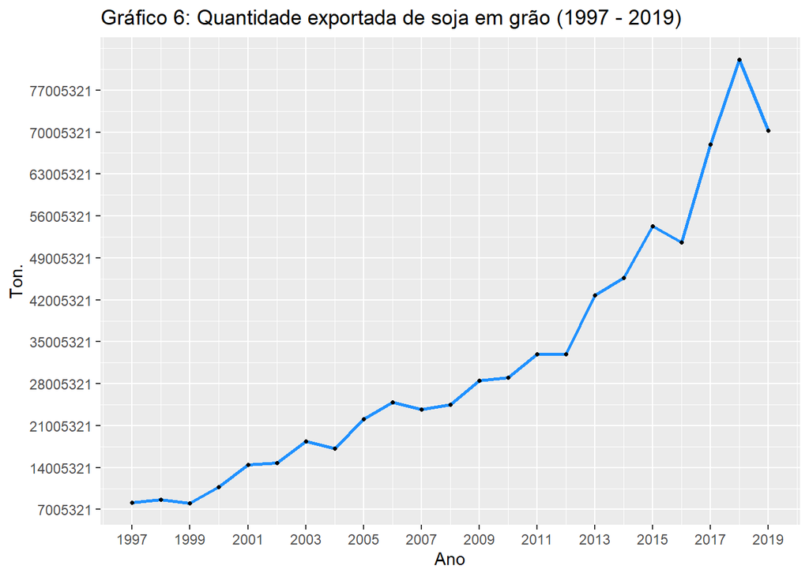

```r
graf_6 <- ggplot(data = q6[q6$product == 'soybeans',], aes(x = as.numeric(year), y = as.numeric(tons))) +
      geom_line(color = "#1e90ff", size = 1)  +
      xlab("Ano") + ylab("Ton.") + labs(title = "Gráfico 6: Quantidade exportada de soja em grão (1997 - 2019)") +
      geom_point(colour = "#000000", size = 0.9) +
      scale_x_continuous(breaks = seq(min(q6$year),max(q6$year), 2)) +
      scale_y_continuous(breaks = seq(min(q6$tons),max(q6$tons), 7000000))

graf_6
```

```r
#Modelo Arima
arima_result = auto.arima(q6$tons[q6$product == 'soybeans'])

summary(arima_result)
```

```
## Series: q6$tons[q6$product == "soybeans"]
## ARIMA(0,1,0) with drift
##
## Coefficients:
##         drift
##       2822960
## s.e.  1223948
##
## sigma^2 estimated as 3.453e+13:  log likelihood=-373.61
## AIC=751.21   AICc=751.84   BIC=753.4
##
## Training set error measures:
##                    ME    RMSE     MAE       MPE     MAPE      MASE       ACF1
## Training set 233.5679 5615000 3823088 -4.175806 11.89947 0.8634138 -0.2063914
```

```r
# Modelo de Previsão
previsaoARIMA = forecast(arima_result, h = 11)

previsaoARIMA$method
```

```
## [1] "ARIMA(0,1,0) with drift"
```

A melhor especificação para realizar a previsão da quantidade exportada de soja em grão é o modelo ARIMA (0,1,0) com constante.

```r
#Valores da previsão
previsao <- as.data.frame(previsaoARIMA)

previsao
```

```
##    Point Forecast    Lo 80     Hi 80    Lo 95     Hi 95
## 24       73123105 65592322  80653887 61605767  84640442
## 25       75946065 65295930  86596199 59658090  92234040
## 26       78769025 65725327  91812722 58820411  98717638
## 27       81591985 66530420  96653549 58557310 104626660
## 28       84414945 67575604 101254286 58661395 110168494
## 29       87237905 68791331 105684478 59026305 115449505
## 30       90060865 70136288 109985441 59588854 120532875
## 31       92883825 71583556 114184093 60307875 125459774
## 32       95706785 73114438 118299131 61154772 130258797
## 33       98529744 74715320 122344169 62108725 134950764
## 34      101352704 76375926 126329483 63154017 139551391
```

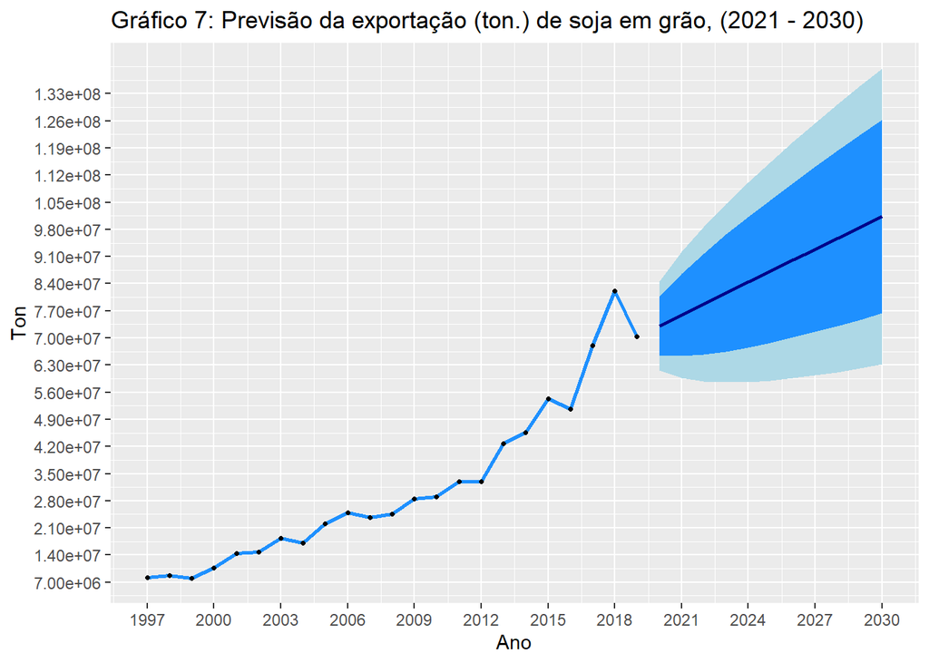

```r
#Gráfico da previsão
graf_7 <- ggplot(data = q6[q6$product == 'soybeans',], aes(x = as.numeric(year), y = as.numeric(tons))) +
      geom_line(color = "#1e90ff", size = 1)  +
      xlab("Ano") + ylab("Ton") + labs(title = "Gráfico 7: Previsão da exportação (ton.) de soja em grão, (2021 - 2030)") +
      geom_point(colour = "#000000", size = 0.9) +
      geom_ribbon(aes(x=c(2020,2021,2022,2023,2024,2025,2026,2027,2028,2029,2030),
                    y=`Point Forecast`,
                    ymax= `Hi 95`, ymin= `Lo 95`),
                 data=previsao, fill="#add8e6") +
      geom_ribbon(aes(x=c(2020,2021,2022,2023,2024,2025,2026,2027,2028,2029,2030),
                      y=`Point Forecast`,
                      ymax= `Hi 80`, ymin= `Lo 80`),
                  data=previsao, fill="#1e90ff") +
      geom_line(aes(x=c(2020,2021,2022,2023,2024,2025,2026,2027,2028,2029,2030),
                    y=`Point Forecast`), data = previsao, color = 'dark blue', size = .8) +
      scale_x_continuous(breaks = seq(min(q6$year),2030, 3)) +
      scale_y_continuous(breaks = seq(0, max(previsao$`Hi 95`), 7000000))

graf_7
```

#### Farelo de Soja

O gráfico, abaixo, apresenta a evolução da quantidade exportada de farelo de soja, pelo Brasil, entre 1997 a 2019.

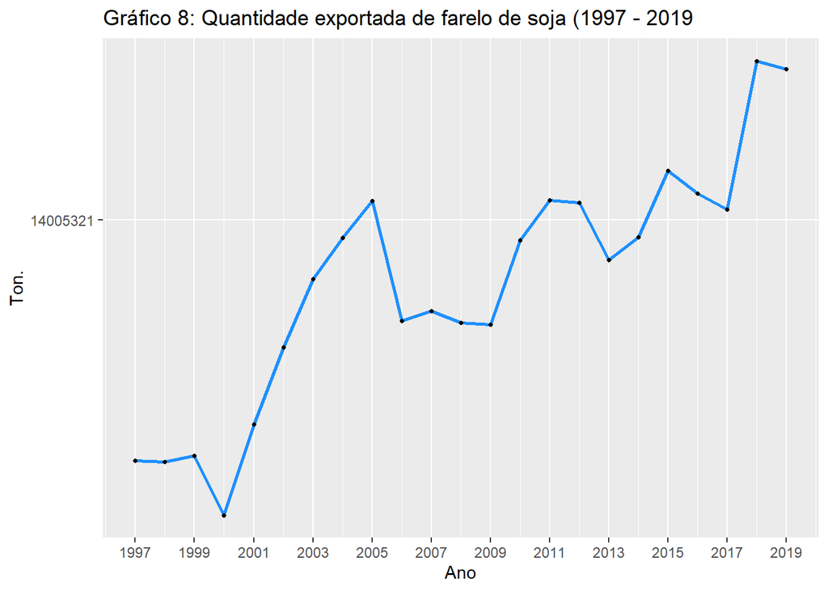

```r
graf_8 <- ggplot(data = q6[q6$product == 'soybean_meal',], aes(x = as.numeric(year), y = as.numeric(tons))) +
      geom_line(color = "#1e90ff", size = 1)  +
      xlab("Ano") + ylab("Ton.") + labs(title = "Gráfico 8: Quantidade exportada de farelo de soja (1997 - 2019") +
      geom_point(colour = "#000000", size = 0.9) +
      scale_x_continuous(breaks = seq(min(q6$year),max(q6$year), 2)) +
      scale_y_continuous(breaks = seq(min(q6$tons),max(q6$tons), 7000000))
graf_8
```

```r
#Modelo Arima
arima_result = auto.arima(q6$tons[q6$product == 'soybean_meal'])

summary(arima_result)
```

```
## Series: q6$tons[q6$product == "soybean_meal"]
## ARIMA(0,1,0)
##
## sigma^2 estimated as 1.022e+12:  log likelihood=-335.4
## AIC=672.8   AICc=673   BIC=673.89
##
## Training set error measures:
##                    ME     RMSE      MAE      MPE     MAPE      MASE        ACF1
## Training set 285843.5 988772.7 724294.9 1.909083 5.580086 0.9570943 -0.04442368
```

```r
# Modelo de Previsão
previsaoARIMA = forecast(arima_result, h = 11)

previsaoARIMA$method
```

```
## [1] "ARIMA(0,1,0)"
```

A melhor especificação para realizar a previsão da quantidade exportada de farelo de soja é o modelo ARIMA (0,1,0).

```r
#Valores da previsão
previsao <- as.data.frame(previsaoARIMA)

previsao
```

```
##    Point Forecast    Lo 80    Hi 80    Lo 95    Hi 95
## 24       16530381 15234738 17826023 14548867 18511895
## 25       16530381 14698066 18362696 13728097 19332665
## 26       16530381 14286262 18774499 13098298 19962464
## 27       16530381 13939096 19121665 12567353 20493409
## 28       16530381 13633236 19427525 12099581 20961181
## 29       16530381 13356718 19704043 11676683 21384079
## 30       16530381 13102433 19958328 11287788 21772974
## 31       16530381 12865751 20195011 10925813 22134949
## 32       16530381 12643454 20417308 10585839 22474923
## 33       16530381 12433200 20627562 10264283 22796478
## 34       16530381 12233221 20827540  9958442 23102319
```

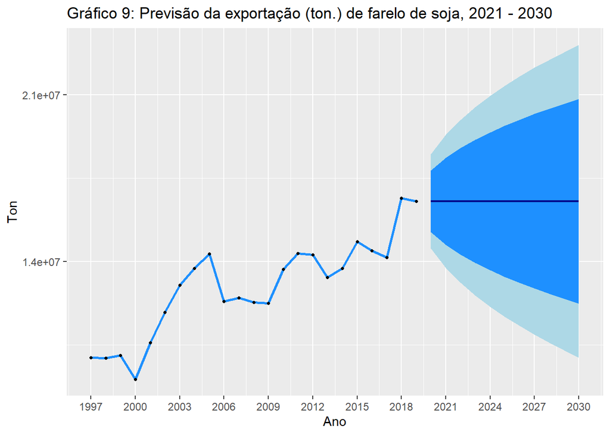

```r
#Gráfico da previsão
graf_9 <- ggplot(data = q6[q6$product == 'soybean_meal',], aes(x = as.numeric(year), y = as.numeric(tons))) +
      geom_line(color = "#1e90ff", size = 1)  +
      xlab("Ano") + ylab("Ton") + labs(title = "Gráfico 9: Previsão da exportação (ton.) de farelo de soja, 2021 - 2030") +
      geom_point(colour = "#000000", size = 0.9) +
      geom_ribbon(aes(x=c(2020,2021,2022,2023,2024,2025,2026,2027,2028,2029,2030),
                    y=`Point Forecast`,
                    ymax= `Hi 95`, ymin= `Lo 95`),
                 data=previsao, fill="#add8e6") +
      geom_ribbon(aes(x=c(2020,2021,2022,2023,2024,2025,2026,2027,2028,2029,2030),
                      y=`Point Forecast`,
                      ymax= `Hi 80`, ymin= `Lo 80`),
                  data=previsao, fill="#1e90ff") +
      geom_line(aes(x=c(2020,2021,2022,2023,2024,2025,2026,2027,2028,2029,2030),
                    y=`Point Forecast`), data = previsao, color = 'dark blue', size = .8) +
      scale_x_continuous(breaks = seq(min(q6$year),2030, 3)) +
      scale_y_continuous(breaks = seq(0, max(previsao$`Hi 95`), 7000000))

graf_9
```

#### Milho

O gráfico, abaixo, apresenta a evolução da quanitdade exportada de milho pelo Brasil, entre 1997 a 2019.

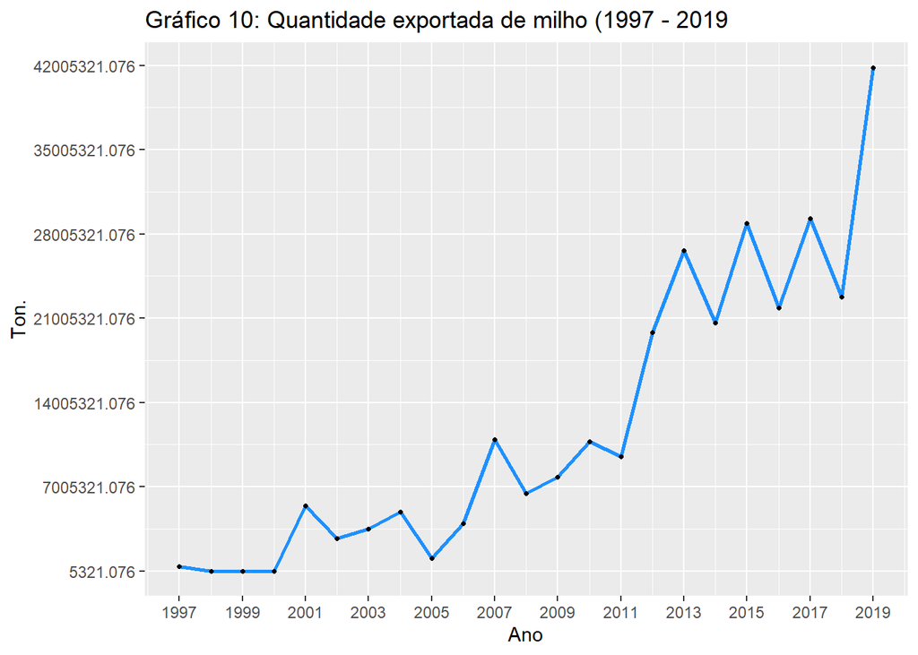

```r
graf_10 <- ggplot(data = q6[q6$product == 'corn',], aes(x = as.numeric(year), y = as.numeric(tons))) +
      geom_line(color = "#1e90ff", size = 1)  +
      xlab("Ano") + ylab("Ton.") + labs(title = "Gráfico 10: Quantidade exportada de milho (1997 - 2019") +
      geom_point(colour = "#000000", size = 0.9) +
      scale_x_continuous(breaks = seq(min(q6$year),max(q6$year), 2)) +
      scale_y_continuous(breaks = seq(min(q6$tons),max(q6$tons), 7000000))
graf_10
```

```r
#Modelo Arima
arima_result = auto.arima(q6$tons[q6$product == 'corn'])

summary(arima_result)
```

```
## Series: q6$tons[q6$product == "corn"]
## ARIMA(1,1,0) with drift
##
## Coefficients:
##           ar1      drift
##       -0.7215  1588877.1
## s.e.   0.1863   610293.3
##
## sigma^2 estimated as 2.555e+13:  log likelihood=-370.12
## AIC=746.25   AICc=747.58   BIC=749.52
##
## Training set error measures:
##                     ME    RMSE     MAE       MPE     MAPE      MASE        ACF1
## Training set -34962.13 4713522 3621820 -5582.242 5602.022 0.7533187 -0.06031409
```

```r
# Modelo de Previsão
previsaoARIMA = forecast(arima_result, h = 11)

previsaoARIMA$method
```

```
## [1] "ARIMA(1,1,0) with drift"
```

A melhor especificação para fazer a previsão da quantidade exportada de milho é o modelo ARIMA (1,1,0) com constante.

```r
#Valores da previsão
previsao <- as.data.frame(previsaoARIMA)

previsao
```

```
##    Point Forecast    Lo 80    Hi 80    Lo 95    Hi 95
## 24       30797508 24319663 37275354 20890499 40704518
## 25       41494154 34769790 48218517 31210126 51778181
## 26       36511730 28025843 44997618 23533685 49489775
## 27       42841834 33923576 51760091 29202536 56481131
## 28       41009892 31021250 50998534 25733582 56286202
## 29       45066907 34568374 55565440 29010786 61123028
## 30       44875010 33587510 56162510 27612269 62137752
## 31       47748725 35935014 59562435 29681213 65816236
## 32       48410585 35950113 60871058 29353937 67467233
## 33       50668309 37692915 63643704 30824156 70512463
## 34       51774610 38235329 65313891 31068067 72481153
```

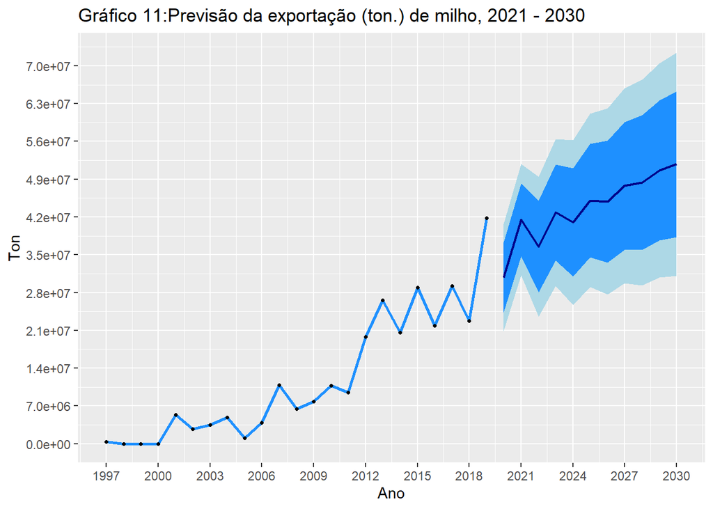

```r
#Gráfico da previsão

graf_11 <- ggplot(data = q6[q6$product == 'corn',], aes(x = as.numeric(year), y = as.numeric(tons))) +
      geom_line(color = "#1e90ff", size = 1)  +
      xlab("Ano") + ylab("Ton") + labs(title = "Gráfico 11:Previsão da exportação (ton.) de milho, 2021 - 2030") +
      geom_point(colour = "#000000", size = 0.9) +
      geom_ribbon(aes(x=c(2020,2021,2022,2023,2024,2025,2026,2027,2028,2029,2030),
                    y=`Point Forecast`,
                    ymax= `Hi 95`, ymin= `Lo 95`),
                 data=previsao, fill="#add8e6") +
      geom_ribbon(aes(x=c(2020,2021,2022,2023,2024,2025,2026,2027,2028,2029,2030),
                      y=`Point Forecast`,
                      ymax= `Hi 80`, ymin= `Lo 80`),
                  data=previsao, fill="#1e90ff") +
      geom_line(aes(x=c(2020,2021,2022,2023,2024,2025,2026,2027,2028,2029,2030),
                    y=`Point Forecast`), data = previsao, color = 'dark blue', size = .8) +
      scale_x_continuous(breaks = seq(min(q6$year),2030, 3)) +
      scale_y_continuous(breaks = seq(0, max(previsao$`Hi 95`), 7000000))

graf_11
```

O modelo de previsão elaborado para a quantidade exportada de soja manteve a tendência de crescimento constante os valores observados da série.

Para o farelo de soja, por mais que o modelo ARIMA (0,1,0) foi indicado como melhor especificação, o modelo de previsão estimou que a quantidade exportada de farelo de soja será constante entre 2020 a 2030. Como a série observada rapresentou grandes variações, a sua projeção ficou prejudicada.

Já a para o milho, o modelo elaborado conseguiu capturar os efeitos cíclicos da exportação do milho, no período observado. A previsão apresenta a manutenção da tendência de crescimento, respeitando o comportamento da série observada.